# Personal Loan Campaign -FikreBitew

## Decision Trees - Hands On

**Background and Context**

AllLife Bank is a US bank that has a growing customer base. The majority of these customers are liability customers (depositors) with varying sizes of deposits. The number of customers who are also borrowers (asset customers) is quite small, and the bank is interested in expanding this base rapidly to bring in more loan business and in the process, earn more through the interest on loans. In particular, the management wants to explore ways of converting its liability customers to personal loan customers (while retaining them as depositors).

A campaign that the bank ran last year for liability customers showed a healthy conversion rate of over 9% success. This has encouraged the retail marketing department to devise campaigns with better target marketing to increase the success ratio.

You as a Data scientist at AllLife bank have to build a model that will help the marketing department to identify the potential customers who have a higher probability of purchasing the loan.

**Objective**

To predict whether a liability customer will buy a personal loan or not. Which variables are most significant. Which segment of customers should be targeted more.

**Data Dictionary**

- ID: Customer ID
- Age: Customer’s age in completed years
- Experience: #years of professional experience
- Income: Annual income of the customer (in thousand dollars)
- ZIP Code: Home Address ZIP code.
- Family: the Family size of the customer
- CCAvg: Average spending on credit cards per month (in thousand dollars)
- Education: Education Level. 1: Undergrad; 2: Graduate;3: Advanced/Professional
- Mortgage: Value of house mortgage if any. (in thousand dollars)
- Personal_Loan: Did this customer accept the personal loan offered in the last campaign?
- Securities_Account: Does the customer have securities account with the bank?
- CD_Account: Does the customer have a certificate of deposit (CD) account with the bank?
- Online: Do customers use internet banking facilities?
- CreditCard: Does the customer use a credit card issued by any other Bank (excluding All life Bank)?

## Import Libraries

```python
import pandas as pd
import numpy as np
import matplotlib.pyplot as plt
%matplotlib inline
import seaborn as sns
from sklearn.model_selection import train_test_split
from sklearn.linear_model import LogisticRegression
from sklearn.tree import DecisionTreeClassifier
from sklearn import tree
import warnings
warnings.filterwarnings("ignore")
from sklearn import metrics
from sklearn.metrics import confusion_matrix,classification_report,accuracy_score
import statsmodels.api as sm
from sklearn import model_selection
from statsmodels.stats.outliers_influence import variance_inflation_factor
from sklearn.metrics import confusion_matrix,ConfusionMatrixDisplay #
```

## Exploratory Data Analysis

```python
url = "Loan_Modelling.csv"
df= pd.read_csv(url)

df= pd.read_csv("Loan_Modelling.csv")
 #several missing values!
```

```python
df.head(10)
```

|  | ID | Age | Experience | Income | ZIPCode | Family | CCAvg | Education | Mortgage | Personal_Loan | Securities_Account | CD_Account | Online | CreditCard |
| --- | --- | --- | --- | --- | --- | --- | --- | --- | --- | --- | --- | --- | --- | --- |
| 0 | 1 | 25 | 1 | 49 | 91107 | 4 | 1.6 | 1 | 0 | 0 | 1 | 0 | 0 | 0 |
| 1 | 2 | 45 | 19 | 34 | 90089 | 3 | 1.5 | 1 | 0 | 0 | 1 | 0 | 0 | 0 |
| 2 | 3 | 39 | 15 | 11 | 94720 | 1 | 1.0 | 1 | 0 | 0 | 0 | 0 | 0 | 0 |
| 3 | 4 | 35 | 9 | 100 | 94112 | 1 | 2.7 | 2 | 0 | 0 | 0 | 0 | 0 | 0 |
| 4 | 5 | 35 | 8 | 45 | 91330 | 4 | 1.0 | 2 | 0 | 0 | 0 | 0 | 0 | 1 |
| 5 | 6 | 37 | 13 | 29 | 92121 | 4 | 0.4 | 2 | 155 | 0 | 0 | 0 | 1 | 0 |
| 6 | 7 | 53 | 27 | 72 | 91711 | 2 | 1.5 | 2 | 0 | 0 | 0 | 0 | 1 | 0 |
| 7 | 8 | 50 | 24 | 22 | 93943 | 1 | 0.3 | 3 | 0 | 0 | 0 | 0 | 0 | 1 |
| 8 | 9 | 35 | 10 | 81 | 90089 | 3 | 0.6 | 2 | 104 | 0 | 0 | 0 | 1 | 0 |
| 9 | 10 | 34 | 9 | 180 | 93023 | 1 | 8.9 | 3 | 0 | 1 | 0 | 0 | 0 | 0 |

```python
df.shape
```

```
(5000, 14)
```

Observation: From the above, we can see that there are 14 attributes and 5000 records in total and that there are no null values, missing values in the data.

Data Type Analysis: There are different variables -

Quantitative Variables

- Age
- Experience
- Income
- NCCAvg
- Mortgage

Categorical Variables Ordinal:

- Family
- Education

Nominal:

- ID
- Zip Code
- Securities Account
- CD Account
- Online
- Credit Card

Observation

- Observation: Quantitative variables should be declared as type float. Nominal variables ID, ZIP Code should be declared as str.

```python
df[["Age","Experience","Income","CCAvg","Mortgage"]] =df[["Age","Experience","Income","CCAvg","Mortgage"]].astype(float)
df[['ID','ZIPCode']] = df[['ID','ZIPCode']].astype('str')
```

```python
df.info()
```

```
<class 'pandas.core.frame.DataFrame'>
RangeIndex: 5000 entries, 0 to 4999
Data columns (total 14 columns):
 #   Column              Non-Null Count  Dtype
---  ------              --------------  -----
 0   ID                  5000 non-null   object
 1   Age                 5000 non-null   float64
 2   Experience          5000 non-null   float64
 3   Income              5000 non-null   float64
 4   ZIPCode             5000 non-null   object
 5   Family              5000 non-null   int64
 6   CCAvg               5000 non-null   float64
 7   Education           5000 non-null   int64
 8   Mortgage            5000 non-null   float64
 9   Personal_Loan       5000 non-null   int64
 10  Securities_Account  5000 non-null   int64
 11  CD_Account          5000 non-null   int64
 12  Online              5000 non-null   int64
 13  CreditCard          5000 non-null   int64
dtypes: float64(5), int64(7), object(2)
memory usage: 547.0+ KB
```

```python
df.describe().T
```

|  | count | mean | std | min | 25% | 50% | 75% | max |
| --- | --- | --- | --- | --- | --- | --- | --- | --- |
| Age | 5000.0 | 45.338400 | 11.463166 | 23.0 | 35.0 | 45.0 | 55.0 | 67.0 |
| Experience | 5000.0 | 20.104600 | 11.467954 | -3.0 | 10.0 | 20.0 | 30.0 | 43.0 |
| Income | 5000.0 | 73.774200 | 46.033729 | 8.0 | 39.0 | 64.0 | 98.0 | 224.0 |
| Family | 5000.0 | 2.396400 | 1.147663 | 1.0 | 1.0 | 2.0 | 3.0 | 4.0 |
| CCAvg | 5000.0 | 1.937938 | 1.747659 | 0.0 | 0.7 | 1.5 | 2.5 | 10.0 |
| ... | ... | ... | ... | ... | ... | ... | ... | ... |
| Personal_Loan | 5000.0 | 0.096000 | 0.294621 | 0.0 | 0.0 | 0.0 | 0.0 | 1.0 |
| Securities_Account | 5000.0 | 0.104400 | 0.305809 | 0.0 | 0.0 | 0.0 | 0.0 | 1.0 |
| CD_Account | 5000.0 | 0.060400 | 0.238250 | 0.0 | 0.0 | 0.0 | 0.0 | 1.0 |
| Online | 5000.0 | 0.596800 | 0.490589 | 0.0 | 0.0 | 1.0 | 1.0 | 1.0 |
| CreditCard | 5000.0 | 0.294000 | 0.455637 | 0.0 | 0.0 | 0.0 | 1.0 | 1.0 |

Observation:

From the above distribution, we could see that the Experience column has negative data. We would need to correct the negative data

```python
df[df['Experience'] < 0]['Experience'].count()
```

```
52
```

```python
df["Experience"] = df["Experience"].apply(abs)
```

```python
df[df['Experience'] < 0]['Experience'].count()
```

```
0
```

Observation:

- Experience field have some negative values, so get the absoulute values for Experience column

```python
df.describe().T
```

|  | count | mean | std | min | 25% | 50% | 75% | max |
| --- | --- | --- | --- | --- | --- | --- | --- | --- |
| Age | 5000.0 | 45.338400 | 11.463166 | 23.0 | 35.0 | 45.0 | 55.0 | 67.0 |
| Experience | 5000.0 | 20.134600 | 11.415189 | 0.0 | 10.0 | 20.0 | 30.0 | 43.0 |
| Income | 5000.0 | 73.774200 | 46.033729 | 8.0 | 39.0 | 64.0 | 98.0 | 224.0 |
| Family | 5000.0 | 2.396400 | 1.147663 | 1.0 | 1.0 | 2.0 | 3.0 | 4.0 |
| CCAvg | 5000.0 | 1.937938 | 1.747659 | 0.0 | 0.7 | 1.5 | 2.5 | 10.0 |
| ... | ... | ... | ... | ... | ... | ... | ... | ... |
| Personal_Loan | 5000.0 | 0.096000 | 0.294621 | 0.0 | 0.0 | 0.0 | 0.0 | 1.0 |
| Securities_Account | 5000.0 | 0.104400 | 0.305809 | 0.0 | 0.0 | 0.0 | 0.0 | 1.0 |
| CD_Account | 5000.0 | 0.060400 | 0.238250 | 0.0 | 0.0 | 0.0 | 0.0 | 1.0 |
| Online | 5000.0 | 0.596800 | 0.490589 | 0.0 | 0.0 | 1.0 | 1.0 | 1.0 |
| CreditCard | 5000.0 | 0.294000 | 0.455637 | 0.0 | 0.0 | 0.0 | 1.0 | 1.0 |

## Dropping Irrelavant column

The variable ID does not add any interesting information. There is no association between a person's customer ID and loan, also it does not provide any general conclusion for future potential loan customers. We can neglect this information for our model prediction.

```python
df= df.drop(["ID"], axis=1)
```

```python
df[df['Experience'] < 0]['Experience'].count()
```

[output not shown]

```python
df[df['Experience'] < 0]['Experience'].value_counts()
```

[output not shown]

```python
df.head()
```

|  | Age | Experience | Income | ZIPCode | Family | CCAvg | Education | Mortgage | Personal_Loan | Securities_Account | CD_Account | Online | CreditCard |
| --- | --- | --- | --- | --- | --- | --- | --- | --- | --- | --- | --- | --- | --- |
| 0 | 25 | 1 | 49 | 91107 | 4 | 1.6 | 1 | 0 | 0 | 1 | 0 | 0 | 0 |
| 1 | 45 | 19 | 34 | 90089 | 3 | 1.5 | 1 | 0 | 0 | 1 | 0 | 0 | 0 |
| 2 | 39 | 15 | 11 | 94720 | 1 | 1.0 | 1 | 0 | 0 | 0 | 0 | 0 | 0 |
| 3 | 35 | 9 | 100 | 94112 | 1 | 2.7 | 2 | 0 | 0 | 0 | 0 | 0 | 0 |
| 4 | 35 | 8 | 45 | 91330 | 4 | 1.0 | 2 | 0 | 0 | 0 | 0 | 0 | 1 |

```python
 df.columns
```

```
Index(['Age', 'Experience', 'Income', 'ZIPCode', 'Family', 'CCAvg',
       'Education', 'Mortgage', 'Personal_Loan', 'Securities_Account',
       'CD_Account', 'Online', 'CreditCard'],
      dtype='object')
```

```python
df.nunique()
```

```
Age                    45
Experience             47
Income                162
ZIPCode               467
Family                  4
CCAvg                 108
Education               3
Mortgage              347
Personal_Loan           2
Securities_Account      2
CD_Account              2
Online                  2
CreditCard              2
dtype: int64
```

Zip Code has 467 distinct value. It is nominal variable. It will not affect the prediction. So we will drop zip code column

```python
# Number of people with zero mortgage
df[df['Mortgage'] == 0]['Mortgage'].value_counts()
```

```
0    3462
Name: Mortgage, dtype: int64
```

```python
# Number of people with zero credit card spending per month
df[df['CCAvg'] == 0]['CCAvg'].value_counts()
```

```
0.0    106
Name: CCAvg, dtype: int64
```

```python
# Value counts of Family column
df['Family'].value_counts()
```

```
1    1472
2    1296
4    1222
3    1010
Name: Family, dtype: int64
```

```python
# Value counts of Securities Account column
df['Securities_Account'].value_counts()
```

```
0    4478
1     522
Name: Securities_Account, dtype: int64
```

```python
# Value counts of CD Account column
df['CD_Account'].value_counts()
```

```
0    4698
1     302
Name: CD_Account, dtype: int64
```

```python
# Value counts of CreditCard column
df['CreditCard'].value_counts()
```

```
0    3530
1    1470
Name: CreditCard, dtype: int64
```

```python
# Value counts of Education column
df['Education'].value_counts()
```

```
1    2096
3    1501
2    1403
Name: Education, dtype: int64
```

```python
# Value counts of Online column
df['Online'].value_counts()
```

```
1    2984
0    2016
Name: Online, dtype: int64
```

## Univariate Analysis

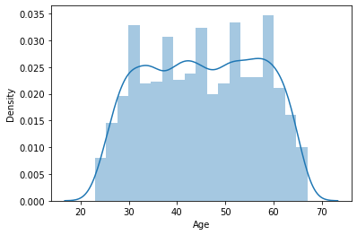

```python
# Age have normal distributions
sns.distplot(df["Age"]);
```

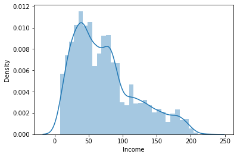

```python
# Income is right skewed distributions
sns.distplot(df["Income"])
```

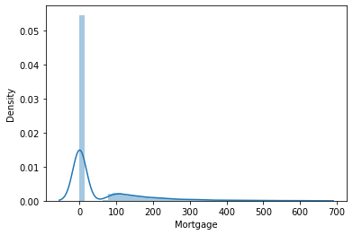

```python
# Mortgage seems to be highly skewed
sns.distplot(df["Mortgage"])
```

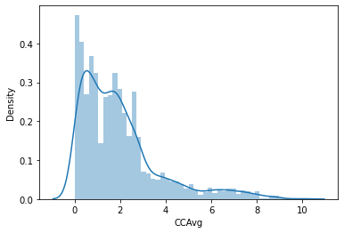

```python
# Credit Card Average is right skewed distributions
sns.distplot(df["CCAvg"])
```

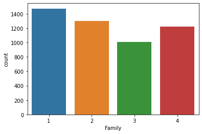

```python
# Count Plot to show Family Distributions
sns.countplot(x='Family',data=df);
```

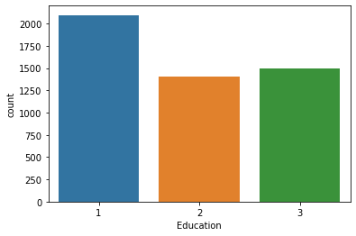

```python
# Count Plot to show Education Distributions
sns.countplot(x='Education',data=df);
```

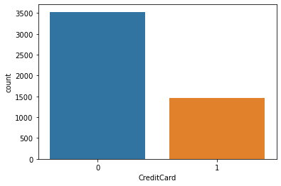

```python
# Count Plot to show CreditCard Distributions
sns.countplot(x='CreditCard',data=df);
```

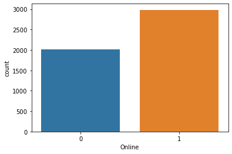

```python
#  Count Plot to show Online Distributions
sns.countplot(x='Online',data=df);
```

## Multivariate Analysis

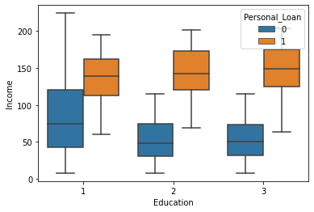

```python
# Influence of income and education on personal loan
sns.boxplot(x='Education',y='Income',hue='Personal_Loan',data=df);
```

Observation : It seems the customers whose education level is 1 is having more income. However customers who has taken the personal loan have the same income levels

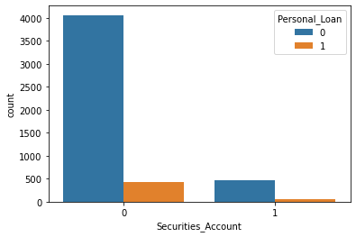

```python
sns.countplot(x="Securities_Account", data=df,hue="Personal_Loan");
```

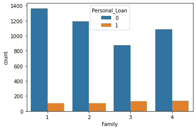

```python
sns.countplot(x='Family',data=df,hue='Personal_Loan');
```

Observation: Family size does not have any impact in personal loan. But it seems families with size of 3 are more likely to take loan. When considering future campaign this might be good association.

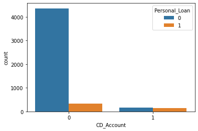

```python
sns.countplot(x='CD_Account',data=df,hue='Personal_Loan');
```

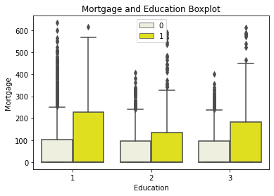

```python
sns.boxplot(x="Education", y='Mortgage', hue="Personal_Loan", data=df,color='yellow')
plt.legend(loc='upper center')
plt.title("Mortgage and Education Boxplot");
```

**Observation**

From the above chart it seems that the value of house mortagage for the non-applicants is much lower than that of applicants. This could be a possible reason for them not applying for a loan or not finding a policy based on there need.

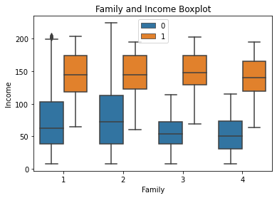

```python
sns.boxplot(x="Family", y="Income", hue="Personal_Loan", data=df)
plt.legend(loc='upper center')
plt.title("Family and Income Boxplot");
```

**Observation**:

Looking at the above plot, families with income less than 100K are less likely to take loan,than families with high income.

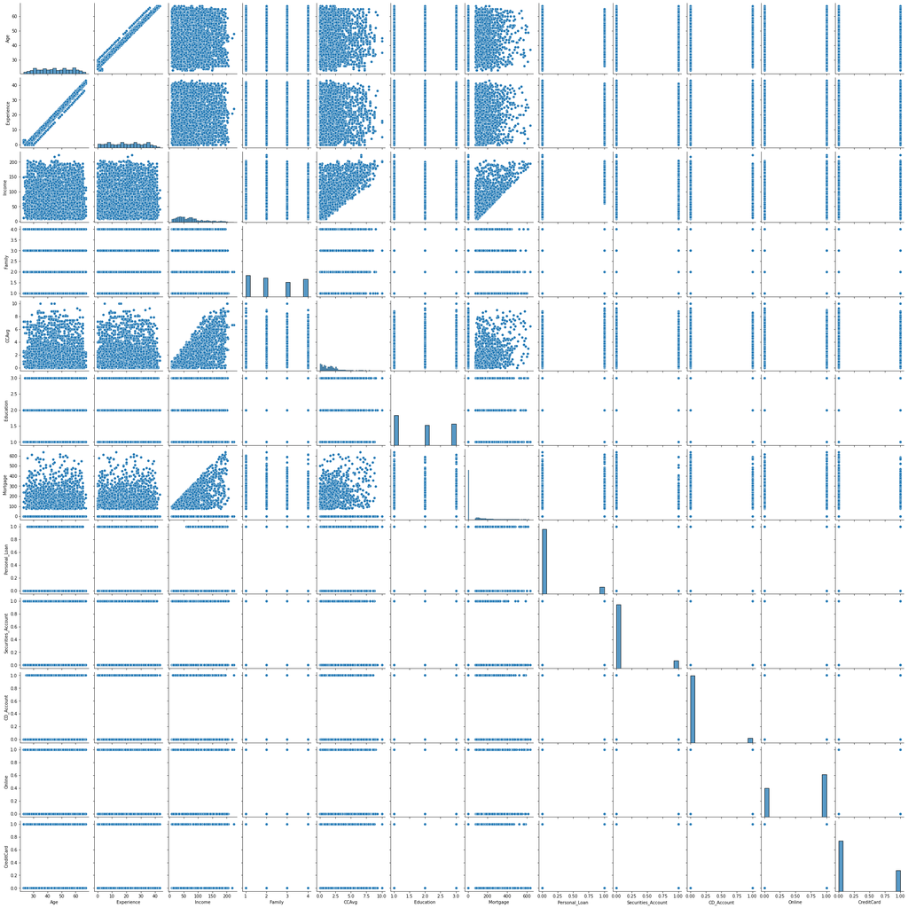

```python
sns.pairplot(df);
```

## Feature Correlation Analysis

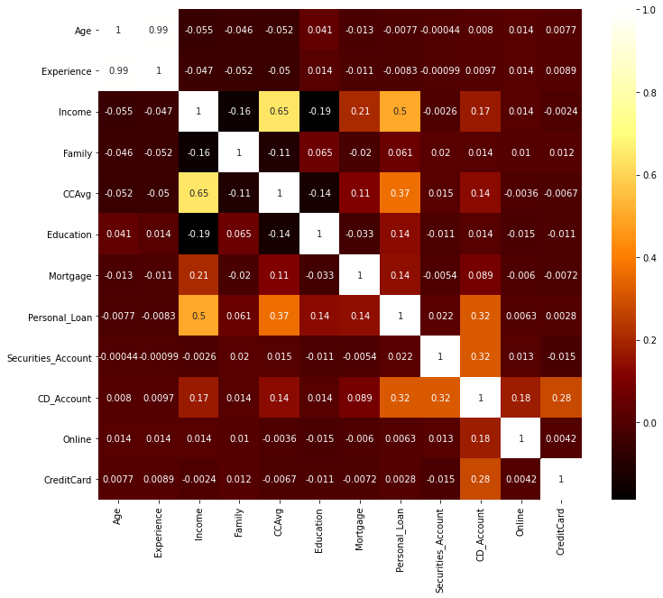

```python
# CCAvg Credit average and income are highly correlated
fig, ax = plt.subplots(figsize=(12,10))
sns.heatmap(df.corr(), cmap='afmhot' , annot = True);
```

Observation :

- Income and CCAvg is moderately correlated.
- Age and Experience is highly correlated. As expected Age and experience are highly correlated and one of them can be dropped.Since we had to handle 0, will drop experience.
- Income, CCAvg have positive association with Personal Loan

## Target Column Distribution

```python
source_counts =pd.DataFrame(df["Personal_Loan"].value_counts()).reset_index()
source_counts.columns =["Labels","Personal_Loan"]
source_counts
```

|  | Labels | Personal_Loan |
| --- | --- | --- |
| 0 | 0 | 4520 |
| 1 | 1 | 480 |

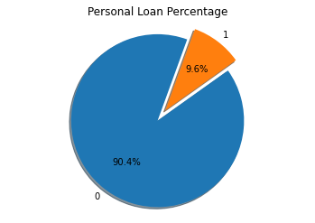

```python
fig1, ax1 = plt.subplots()
explode = (0, 0.15)
ax1.pie(source_counts["Personal_Loan"], explode=explode, labels=source_counts["Labels"], autopct='%1.1f%%',
        shadow=True, startangle=70)
ax1.axis('equal')  # Equal aspect ratio ensures that pie is drawn as a circle.
plt.title("Personal Loan Percentage")
plt.show()
```

## DATA PREPARATION

```python
## drop the ID column as it has 5000 unique values, and does not add value to the dataset
df=df.drop(['ID','ZIPCode'],axis=1)
# "Experience" column has -ve values which is not possible.
# The -ve values seem to be in the same range as other values. So, May be Typo Errors
# Convert all negative values in the 'Experience' column into positive
df['Experience']=df['Experience'].abs()

# Age and Experience is highly correlated. As expected Age and experience are highly correlated and one of them can be dropped.Since we had to handle 0, will drop experience.

df=df.drop(['Experience'],axis=1)
# One hot encoding of Categorical Column 'Education'
df=pd.get_dummies(df,columns=['Education', 'Family'],drop_first=True)
##df=df.drop('Education_AP',axis=1)
df.head()
```

|  | Age | Income | CCAvg | Mortgage | Personal_Loan | Securities_Account | CD_Account | Online | CreditCard | Education_2 | Education_3 | Family_2 | Family_3 | Family_4 |
| --- | --- | --- | --- | --- | --- | --- | --- | --- | --- | --- | --- | --- | --- | --- |
| 0 | 25 | 49 | 1.6 | 0 | 0 | 1 | 0 | 0 | 0 | 0 | 0 | 0 | 0 | 1 |
| 1 | 45 | 34 | 1.5 | 0 | 0 | 1 | 0 | 0 | 0 | 0 | 0 | 0 | 1 | 0 |
| 2 | 39 | 11 | 1.0 | 0 | 0 | 0 | 0 | 0 | 0 | 0 | 0 | 0 | 0 | 0 |
| 3 | 35 | 100 | 2.7 | 0 | 0 | 0 | 0 | 0 | 0 | 1 | 0 | 0 | 0 | 0 |
| 4 | 35 | 45 | 1.0 | 0 | 0 | 0 | 0 | 0 | 1 | 1 | 0 | 0 | 0 | 1 |

## Split Train and Test Data

```python
X = df.drop(["Personal_Loan"], axis=1)
y = df.pop("Personal_Loan")
```

```python
X_train, X_test, y_train, y_test = train_test_split(X, y, test_size=.30, random_state=1)
```

```python
X_train.head()
```

|  | Age | Income | CCAvg | Mortgage | Securities_Account | CD_Account | Online | CreditCard | Education_2 | Education_3 | Family_2 | Family_3 | Family_4 |
| --- | --- | --- | --- | --- | --- | --- | --- | --- | --- | --- | --- | --- | --- |
| 1334 | 47 | 35 | 1.3 | 0 | 0 | 0 | 1 | 0 | 0 | 0 | 1 | 0 | 0 |
| 4768 | 38 | 39 | 2.0 | 0 | 0 | 0 | 1 | 0 | 1 | 0 | 0 | 0 | 0 |
| 65 | 59 | 131 | 3.8 | 0 | 0 | 0 | 1 | 1 | 0 | 0 | 0 | 0 | 0 |
| 177 | 29 | 65 | 1.8 | 244 | 0 | 0 | 0 | 0 | 1 | 0 | 0 | 0 | 1 |
| 4489 | 39 | 21 | 0.2 | 0 | 0 | 0 | 1 | 0 | 1 | 0 | 0 | 1 | 0 |

Check the split of data

```python
print("{0:0.2f}% data is in training set".format((len(X_train)/len(df.index)) * 100))
print("{0:0.2f}% data is in test set".format((len(X_test)/len(df.index)) * 100))
```

```
70.00% data is in training set
30.00% data is in test set
```

```python
y_train.value_counts()
```

```
0    3169
1     331
Name: Personal_Loan, dtype: int64
```

```python
### Let us check the effect of scaling (convert all dimensions to z scores)
```

```python
from sklearn import preprocessing
X_train_scaled = preprocessing.scale(X_train)
X_test_scaled = preprocessing.scale(X_test)
```

## Predictions through various Classification Models

### A.Logistic Regression

```python
#Build the logistic regression model
logisticRegr = LogisticRegression()
```

```python
logisticRegr.fit(X_train, y_train)
```

```
LogisticRegression()
```

```python
# Use score method to get accuracy of train model
logreg_train_score = logisticRegr.score(X_train, y_train)
print('Train Accuracy Score:', np.round((logreg_train_score),4))

# Use score method to get accuracy of test model
logreg_test_score = logisticRegr.score(X_test, y_test)
print('Test Accuracy Score:', np.round((logreg_test_score),4))
```

```
Train Accuracy Score: 0.9583
Test Accuracy Score: 0.9513
```

```python
#Predict for train set
pred_train = logisticRegr.predict(X_train)

#Confusion Matrix
logreg_cm_train = pd.DataFrame(confusion_matrix(y_train,pred_train).T,index=['No', 'Yes'], columns=['No', 'Yes'])
logreg_cm_train.index.name = "Predicted"
logreg_cm_train.columns.name = "True"
logreg_cm_train
```

| True Predicted | No | Yes |
| --- | --- | --- |
| No | 3137 | 114 |
| Yes | 32 | 217 |

```python
#Predict for test set
pred_test = logisticRegr.predict(X_test)

#Confusion Matrix
logreg_cm_test = pd.DataFrame(confusion_matrix(y_test,pred_test).T,index=['No', 'Yes'], columns=['No', 'Yes'])
logreg_cm_test.index.name = "Predicted"
logreg_cm_test.columns.name = "True"
logreg_cm_test
```

| True Predicted | No | Yes |
| --- | --- | --- |
| No | 1338 | 60 |
| Yes | 13 | 89 |

**Test Assumption- MultiCollinearity**

we will have to check and remove multicollinearity from the data to get reliable coefficients and p-values. There are different ways of detecting (or testing) multi-collinearity, one such way is the Variation Inflation Factor.* General Rule of thumb: If VIF is 1 then there is no correlation among the predictor and the remaining predictor variables. Whereas if VIF exceeds 5, we say it shows signs of high multi-collinearity. But the purpose of the analysis should dictate which threshold to use.

```python
X_train_num = X_train.astype(float).copy()
```

```python
vif_series1 = pd.Series([variance_inflation_factor(X_train_num.values,i) for i in range(X_train_num.shape[1])],index=X_train_num.columns, dtype = float)
print('Series before feature selection: \n\n{}\n'.format(vif_series1))
```

```
Series before feature selection:

Age                   6.626987
Income                6.075087
CCAvg                 3.881010
Mortgage              1.367397
Securities_Account    1.264882
CD_Account            1.409194
Online                2.405147
CreditCard            1.542866
Education_2           1.679063
Education_3           1.689950
Family_2              1.801462
Family_3              1.646289
Family_4              1.722648
dtype: float64
```

**Observations:**

Roc -Auc curve on Train data

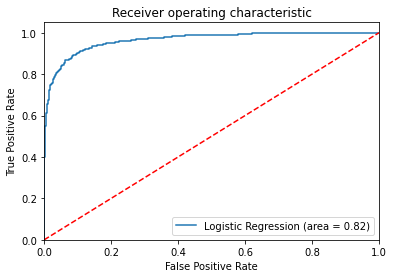

```python
#AUC ROC curve
from sklearn.metrics import roc_auc_score
from sklearn.metrics import roc_curve

logit_roc_auc = roc_auc_score(y_train, logisticRegr.predict(X_train))
fpr, tpr, thresholds = roc_curve(y_train, logisticRegr.predict_proba(X_train)[:,1])
plt.figure()
plt.plot(fpr, tpr, label='Logistic Regression (area = %0.2f)' % logit_roc_auc)
plt.plot([0, 1], [0, 1],'r--')
plt.xlim([0.0, 1.0])
plt.ylim([0.0, 1.05])
plt.xlabel('False Positive Rate')
plt.ylabel('True Positive Rate')
plt.title('Receiver operating characteristic')
plt.legend(loc="lower right")
plt.savefig('Log_ROC')
plt.show()
```

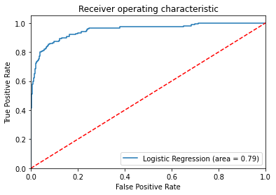

```python
#AUC ROC curve
from sklearn.metrics import roc_auc_score
from sklearn.metrics import roc_curve

logit_roc_auc = roc_auc_score(y_test, logisticRegr.predict(X_test))
fpr, tpr, thresholds = roc_curve(y_test, logisticRegr.predict_proba(X_test)[:,1])
plt.figure()
plt.plot(fpr, tpr, label='Logistic Regression (area = %0.2f)' % logit_roc_auc)
plt.plot([0, 1], [0, 1],'r--')
plt.xlim([0.0, 1.0])
plt.ylim([0.0, 1.05])
plt.xlabel('False Positive Rate')
plt.ylabel('True Positive Rate')
plt.title('Receiver operating characteristic')
plt.legend(loc="lower right")
plt.savefig('Log_ROC')
plt.show()
```

```python
#Calculate auc score
auc_score = metrics.roc_auc_score(y_test, logisticRegr.predict_proba(X_test)[:,1])
round( float( auc_score ), 2 )
```

```
0.95
```

```python
# summarize the fit of the model
logreg_accuracy = np.round( metrics.accuracy_score( y_test, pred_test ), 4 )
print( 'Total Accuracy : ', logreg_accuracy)
print('\n')
print('Metrics Classification Report \n',metrics.classification_report(y_test, pred_test))
```

```
Total Accuracy :  0.9513


Metrics Classification Report
               precision    recall  f1-score   support

           0       0.96      0.99      0.97      1351
           1       0.87      0.60      0.71       149

    accuracy                           0.95      1500
   macro avg       0.91      0.79      0.84      1500
weighted avg       0.95      0.95      0.95      1500
```

**Observation:**

```python
# Find out coefficients of all the attributes and show the output in a data frame with column names?
coef_list=[]
col_list=[]
for i,col in enumerate(X_train.columns):
    coef_list.append(logisticRegr.coef_[0][i])
    col_list.append(col)

coef_df=pd.DataFrame({'Attributes':col_list, 'Coeff':coef_list})
new_row={'Attributes':'Intercept','Coeff':logisticRegr.intercept_}
coef_df.append(new_row,ignore_index=True)
#coef_df['Coeff']=coef_df['Coeff'].sort_values(ascending=False)
coef_df.sort_values(by='Coeff',ascending=False)
```

|  | Attributes | Coeff |
| --- | --- | --- |
| 5 | CD_Account | 4.464402 |
| 9 | Education_3 | 3.179490 |
| 8 | Education_2 | 2.875778 |
| 11 | Family_3 | 0.894950 |
| 12 | Family_4 | 0.276552 |
| ... | ... | ... |
| 0 | Age | -0.011098 |
| 10 | Family_2 | -0.606757 |
| 6 | Online | -0.956939 |
| 4 | Securities_Account | -1.411545 |
| 7 | CreditCard | -1.945100 |

**Feature Importance:**

The features that influence the prediction of personal loan positively are:

- CD Account
- Education_2
- EDucation_3
- Family_3
- Family_4

The features that influence the prediction of personal loan negatively are:

- CreditCard
- Securities_Account
- Online
- Family_2
- Age

Mortgage and Income DO NOT have much influence on the 'Loan Status'

## B. Decision Tree Model

We will build our model using the DecisionTreeClassifier function. Using default 'gini' criteria to split. Other option include 'entropy'.

```python
url = "Loan_Modelling.csv"
df= pd.read_csv(url)

df= pd.read_csv("Loan_Modelling.csv")
df['Experience']=df['Experience'].abs()

## drop the ID column as it has 5000 unique values, and does not add value to the dataset
df=df.drop(['ID', 'ZIPCode'],axis=1)
# "Experience" column has -ve values which is not possible.
# The -ve values seem to be in the same range as other values. So, May be Typo Errors
# Convert all negative values in the 'Experience' column into positive
df['Experience']=df['Experience'].abs()

# Age and Experience is highly correlated. As expected Age and experience are highly correlated and one of them can be dropped.Since we had to handle 0, will drop experience.

# One hot encoding of Categorical Column 'Education'
df=pd.get_dummies(df,columns=['Education', 'Family'],drop_first=True)
##df=df.drop('Education_AP',axis=1)
df.head()
```

|  | Age | Experience | Income | CCAvg | Mortgage | Personal_Loan | Securities_Account | CD_Account | Online | CreditCard | Education_2 | Education_3 | Family_2 | Family_3 | Family_4 |
| --- | --- | --- | --- | --- | --- | --- | --- | --- | --- | --- | --- | --- | --- | --- | --- |
| 0 | 25 | 1 | 49 | 1.6 | 0 | 0 | 1 | 0 | 0 | 0 | 0 | 0 | 0 | 0 | 1 |
| 1 | 45 | 19 | 34 | 1.5 | 0 | 0 | 1 | 0 | 0 | 0 | 0 | 0 | 0 | 1 | 0 |
| 2 | 39 | 15 | 11 | 1.0 | 0 | 0 | 0 | 0 | 0 | 0 | 0 | 0 | 0 | 0 | 0 |
| 3 | 35 | 9 | 100 | 2.7 | 0 | 0 | 0 | 0 | 0 | 0 | 1 | 0 | 0 | 0 | 0 |
| 4 | 35 | 8 | 45 | 1.0 | 0 | 0 | 0 | 0 | 0 | 1 | 1 | 0 | 0 | 0 | 1 |

```python
X = df.drop(["Personal_Loan"], axis=1)
y = df.pop("Personal_Loan")
```

```python
X_train, X_test, y_train, y_test = train_test_split(X, y, test_size=.30, random_state=1)
```

```python
dTree = DecisionTreeClassifier(criterion = 'gini', random_state=1)
dTree.fit(X_train, y_train)
```

```
DecisionTreeClassifier(random_state=1)
```

## Scoring our Decision Tree

```python
print("Accuracy on training set : ",dTree.score(X_train, y_train))
print("Accuracy on test set : ",dTree.score(X_test, y_test))
```

```
Accuracy on training set :  1.0
Accuracy on test set :  0.9806666666666667
```

```python
#Checking number of positives
y.sum(axis = 0)
```

```
480
```

```python
## Function to create confusion matrix
def make_confusion_matrix(model,y_actual,labels=[1, 0]):
    '''
    model : classifier to predict values of X
    y_actual : ground truth

    '''
    y_predict = model.predict(X_test)
    cm=metrics.confusion_matrix( y_actual, y_predict, labels=[0, 1])
    df_cm = pd.DataFrame(cm, index = [i for i in ["Actual - No","Actual - Yes"]],
                  columns = [i for i in ['Predicted - No','Predicted - Yes']])
    group_counts = ["{0:0.0f}".format(value) for value in
                cm.flatten()]
    group_percentages = ["{0:.2%}".format(value) for value in
                         cm.flatten()/np.sum(cm)]
    labels = [f"{v1}\n{v2}" for v1, v2 in
              zip(group_counts,group_percentages)]
    labels = np.asarray(labels).reshape(2,2)
    plt.figure(figsize = (10,7))
    sns.heatmap(df_cm, annot=labels,fmt='')
    plt.ylabel('True label')
    plt.xlabel('Predicted label')
```

```python
##  Function to calculate recall score
def get_recall_score(model):
    '''
    model : classifier to predict values of X

    '''
    pred_train = model.predict(X_train)
    pred_test = model.predict(X_test)
    print("Recall on training set : ",metrics.recall_score(y_train,pred_train))
    print("Recall on test set : ",metrics.recall_score(y_test,pred_test))
```

## Confusion Matrix

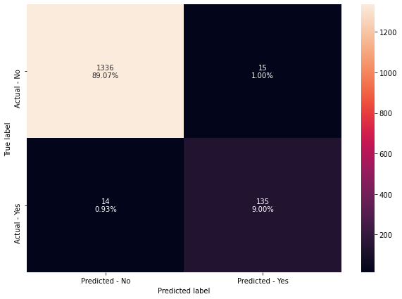

```python
make_confusion_matrix(dTree,y_test)
```

```python
# Recall on train and test
get_recall_score(dTree)
```

```
Recall on training set :  1.0
Recall on test set :  0.9060402684563759
```

## Visualizing the Decision Tree

```python
feature_names = list(X.columns)
print(feature_names)
```

```
['Age', 'Experience', 'Income', 'CCAvg', 'Mortgage', 'Securities_Account', 'CD_Account', 'Online', 'CreditCard', 'Education_2', 'Education_3', 'Family_2', 'Family_3', 'Family_4']
```

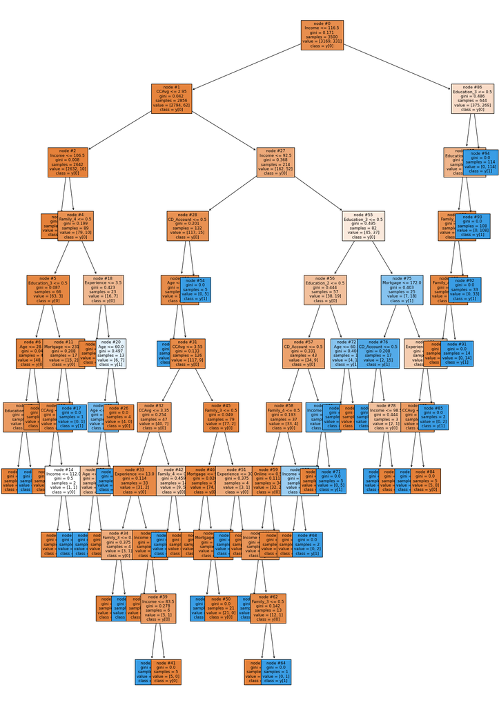

```python
plt.figure(figsize=(20,30))
tree.plot_tree(dTree,feature_names=feature_names,filled=True,fontsize=9,node_ids=True,class_names=True)
plt.show()
```

```python
# Text report showing the rules of a decision tree -

print(tree.export_text(dTree,feature_names=feature_names,show_weights=True))
```

```
|--- Income <= 116.50
|   |--- CCAvg <= 2.95
|   |   |--- Income <= 106.50
|   |   |   |--- weights: [2553.00, 0.00] class: 0
|   |   |--- Income >  106.50
|   |   |   |--- Family_4 <= 0.50
|   |   |   |   |--- Education_3 <= 0.50
|   |   |   |   |   |--- Age <= 28.50
|   |   |   |   |   |   |--- Education_2 <= 0.50
|   |   |   |   |   |   |   |--- weights: [5.00, 0.00] class: 0
|   |   |   |   |   |   |--- Education_2 >  0.50
|   |   |   |   |   |   |   |--- weights: [0.00, 1.00] class: 1
|   |   |   |   |   |--- Age >  28.50
|   |   |   |   |   |   |--- weights: [43.00, 0.00] class: 0
|   |   |   |   |--- Education_3 >  0.50
|   |   |   |   |   |--- Mortgage <= 231.00
|   |   |   |   |   |   |--- CCAvg <= 1.95
|   |   |   |   |   |   |   |--- weights: [14.00, 0.00] class: 0
|   |   |   |   |   |   |--- CCAvg >  1.95
|   |   |   |   |   |   |   |--- Income <= 112.00
|   |   |   |   |   |   |   |   |--- weights: [1.00, 0.00] class: 0
|   |   |   |   |   |   |   |--- Income >  112.00
|   |   |   |   |   |   |   |   |--- weights: [0.00, 1.00] class: 1
|   |   |   |   |   |--- Mortgage >  231.00
|   |   |   |   |   |   |--- weights: [0.00, 1.00] class: 1
|   |   |   |--- Family_4 >  0.50
|   |   |   |   |--- Experience <= 3.50
|   |   |   |   |   |--- weights: [10.00, 0.00] class: 0
|   |   |   |   |--- Experience >  3.50
|   |   |   |   |   |--- Age <= 60.00
|   |   |   |   |   |   |--- Age <= 32.50
|   |   |   |   |   |   |   |--- Age <= 29.50
|   |   |   |   |   |   |   |   |--- weights: [0.00, 1.00] class: 1
|   |   |   |   |   |   |   |--- Age >  29.50
|   |   |   |   |   |   |   |   |--- weights: [2.00, 0.00] class: 0
|   |   |   |   |   |   |--- Age >  32.50
|   |   |   |   |   |   |   |--- weights: [0.00, 6.00] class: 1
|   |   |   |   |   |--- Age >  60.00
|   |   |   |   |   |   |--- weights: [4.00, 0.00] class: 0
|   |--- CCAvg >  2.95
```

[output cut: 87 more lines]

```
|   |   |   |   |   |   |--- weights: [0.00, 2.00] class: 1
|--- Income >  116.50
|   |--- Education_3 <= 0.50
|   |   |--- Education_2 <= 0.50
|   |   |   |--- Family_3 <= 0.50
|   |   |   |   |--- Family_4 <= 0.50
|   |   |   |   |   |--- weights: [375.00, 0.00] class: 0
|   |   |   |   |--- Family_4 >  0.50
|   |   |   |   |   |--- weights: [0.00, 14.00] class: 1
|   |   |   |--- Family_3 >  0.50
|   |   |   |   |--- weights: [0.00, 33.00] class: 1
|   |   |--- Education_2 >  0.50
|   |   |   |--- weights: [0.00, 108.00] class: 1
|   |--- Education_3 >  0.50
|   |   |--- weights: [0.00, 114.00] class: 1
```

```python
# importance of features in the tree building ( The importance of a feature is computed as the
#(normalized) total reduction of the criterion brought by that feature. It is also known as the Gini importance )

print (pd.DataFrame(dTree.feature_importances_, columns = ["Imp"], index = X_train.columns).sort_values(by = 'Imp', ascending = False))
```

```
                         Imp
Income              0.312575
Education_2         0.238344
Education_3         0.165787
Family_3            0.100618
Family_4            0.062971
CCAvg               0.046423
CD_Account          0.026348
Age                 0.023656
Experience          0.011991
Mortgage            0.010725
Online              0.000561
Securities_Account  0.000000
CreditCard          0.000000
Family_2            0.000000
```

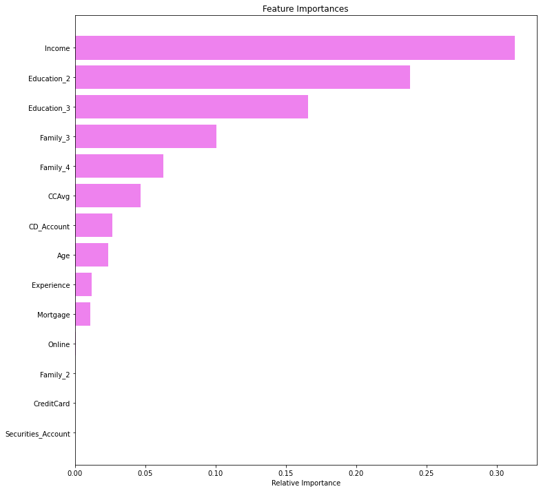

```python
importances = dTree.feature_importances_
indices = np.argsort(importances)

plt.figure(figsize=(12,12))
plt.title('Feature Importances')
plt.barh(range(len(indices)), importances[indices], color='violet', align='center')
plt.yticks(range(len(indices)), [feature_names[i] for i in indices])
plt.xlabel('Relative Importance')
plt.show()
```

- According to the decision tree model, Income is the most important variable for predicting the customer personal loan.

**The tree above is very complex, and overfits the data.**

## Reducing over fitting

- In general, the deeper you allow your tree to grow, the more complex your model will become because you will have more splits and it captures more information about the data and this is one of the root causes of overfitting
- Let's try Limiting the max_depth of tree to 5

```python
dTree1 = DecisionTreeClassifier(criterion = 'gini',max_depth=5,random_state=1)
dTree1.fit(X_train, y_train)
```

```
DecisionTreeClassifier(max_depth=5, random_state=1)
```

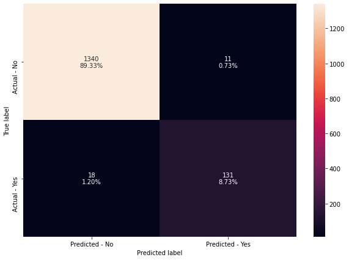

```python
make_confusion_matrix(dTree1, y_test)
```

```python
# Accuracy on train and test
print("Accuracy on training set : ",dTree1.score(X_train, y_train))
print("Accuracy on test set : ",dTree1.score(X_test, y_test))
# Recall on train and test
get_recall_score(dTree1)
```

```
Accuracy on training set :  0.9897142857142858
Accuracy on test set :  0.9806666666666667
Recall on training set :  0.9274924471299094
Recall on test set :  0.8791946308724832
```

- Recall on training set has reduced from 1 to 0.92 but this is an improvement because now the model is not overfitting and we have a generalized model.

## Visualizing the Decision Tree

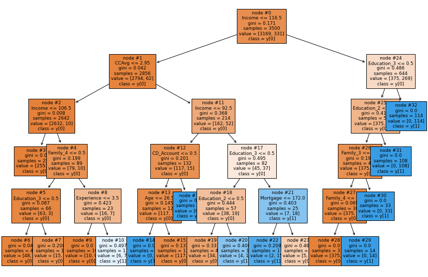

```python
plt.figure(figsize=(15,10))

tree.plot_tree(dTree1,feature_names=feature_names,filled=True,fontsize=9,node_ids=True,class_names=True)
plt.show()
```

```python
# Text report showing the rules of a decision tree -

print(tree.export_text(dTree1,feature_names=feature_names,show_weights=True))
```

```
|--- Income <= 116.50
|   |--- CCAvg <= 2.95
|   |   |--- Income <= 106.50
|   |   |   |--- weights: [2553.00, 0.00] class: 0
|   |   |--- Income >  106.50
|   |   |   |--- Family_4 <= 0.50
|   |   |   |   |--- Education_3 <= 0.50
|   |   |   |   |   |--- weights: [48.00, 1.00] class: 0
|   |   |   |   |--- Education_3 >  0.50
|   |   |   |   |   |--- weights: [15.00, 2.00] class: 0
|   |   |   |--- Family_4 >  0.50
|   |   |   |   |--- Experience <= 3.50
|   |   |   |   |   |--- weights: [10.00, 0.00] class: 0
|   |   |   |   |--- Experience >  3.50
|   |   |   |   |   |--- weights: [6.00, 7.00] class: 1
|   |--- CCAvg >  2.95
|   |   |--- Income <= 92.50
|   |   |   |--- CD_Account <= 0.50
|   |   |   |   |--- Age <= 26.50
|   |   |   |   |   |--- weights: [0.00, 1.00] class: 1
|   |   |   |   |--- Age >  26.50
|   |   |   |   |   |--- weights: [117.00, 9.00] class: 0
|   |   |   |--- CD_Account >  0.50
|   |   |   |   |--- weights: [0.00, 5.00] class: 1
|   |   |--- Income >  92.50
|   |   |   |--- Education_3 <= 0.50
|   |   |   |   |--- Education_2 <= 0.50
|   |   |   |   |   |--- weights: [34.00, 9.00] class: 0
|   |   |   |   |--- Education_2 >  0.50
|   |   |   |   |   |--- weights: [4.00, 10.00] class: 1
|   |   |   |--- Education_3 >  0.50
|   |   |   |   |--- Mortgage <= 172.00
|   |   |   |   |   |--- weights: [2.00, 15.00] class: 1
|   |   |   |   |--- Mortgage >  172.00
|   |   |   |   |   |--- weights: [5.00, 3.00] class: 0
|--- Income >  116.50
|   |--- Education_3 <= 0.50
|   |   |--- Education_2 <= 0.50
|   |   |   |--- Family_3 <= 0.50
|   |   |   |   |--- Family_4 <= 0.50
|   |   |   |   |   |--- weights: [375.00, 0.00] class: 0
|   |   |   |   |--- Family_4 >  0.50
|   |   |   |   |   |--- weights: [0.00, 14.00] class: 1
|   |   |   |--- Family_3 >  0.50
|   |   |   |   |--- weights: [0.00, 33.00] class: 1
|   |   |--- Education_2 >  0.50
|   |   |   |--- weights: [0.00, 108.00] class: 1
|   |--- Education_3 >  0.50
|   |   |--- weights: [0.00, 114.00] class: 1
```

- The tree has become readable now but the recall on test set has not improved.

```python
# importance of features in the tree building ( The importance of a feature is computed as the
#(normalized) total reduction of the criterion brought by that feature. It is also known as the Gini importance )

print (pd.DataFrame(dTree1.feature_importances_, columns = ["Imp"], index = X_train.columns).sort_values(by = 'Imp', ascending = False))
```

```
                         Imp
Income              0.328442
Education_2         0.259788
Education_3         0.182836
Family_3            0.104026
Family_4            0.053870
CCAvg               0.041683
CD_Account          0.015024
Experience          0.006030
Mortgage            0.005153
Age                 0.003148
Securities_Account  0.000000
Online              0.000000
CreditCard          0.000000
Family_2            0.000000
```

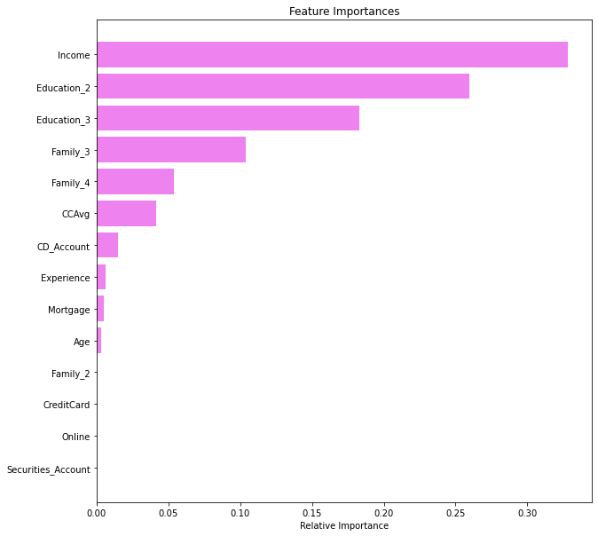

```python
importances = dTree1.feature_importances_
indices = np.argsort(importances)

plt.figure(figsize=(10,10))
plt.title('Feature Importances')
plt.barh(range(len(indices)), importances[indices], color='violet', align='center')
plt.yticks(range(len(indices)), [feature_names[i] for i in indices])
plt.xlabel('Relative Importance')
plt.show()
```

### Using GridSearch for Hyperparameter tuning of our tree model

```python
from sklearn.model_selection import GridSearchCV
```

```python
# Choose the type of classifier.
estimator = DecisionTreeClassifier(random_state=1)

# Grid of parameters to choose from
## add from article
parameters = {'max_depth': np.arange(1,10),
              'min_samples_leaf': [1, 2, 5, 7, 10,15,20],
              'max_leaf_nodes' : [2, 3, 5, 10],
              'min_impurity_decrease': [0.001,0.01,0.1]
             }

# Type of scoring used to compare parameter combinations
acc_scorer = metrics.make_scorer(metrics.recall_score)

# Run the grid search
grid_obj = GridSearchCV(estimator, parameters, scoring=acc_scorer,cv=5)
grid_obj = grid_obj.fit(X_train, y_train)

# Set the clf to the best combination of parameters
estimator = grid_obj.best_estimator_

# Fit the best algorithm to the data.
estimator.fit(X_train, y_train)
```

```
DecisionTreeClassifier(max_depth=5, max_leaf_nodes=10,
                       min_impurity_decrease=0.001, min_samples_leaf=5,
                       random_state=1)
```

## Confusion Matrix - decision tree with tuned hyperparameters

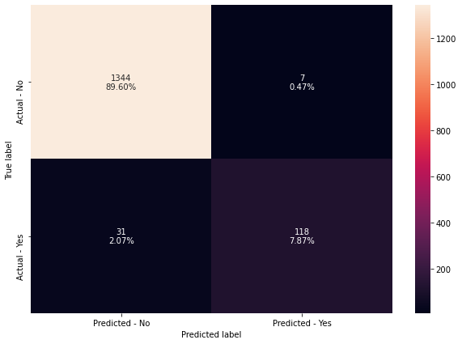

```python
make_confusion_matrix(estimator,y_test)
```

```python
# Accuracy on train and test
print("Accuracy on training set : ",estimator.score(X_train, y_train))
print("Accuracy on test set : ",estimator.score(X_test, y_test))
# Recall on train and test
get_recall_score(estimator)
```

```
Accuracy on training set :  0.9868571428571429
Accuracy on test set :  0.9746666666666667
Recall on training set :  0.8821752265861027
Recall on test set :  0.7919463087248322
```

- Recall has not improved for both train and test set after hyperparameter tuning.

## Visualizing the Decision Tree

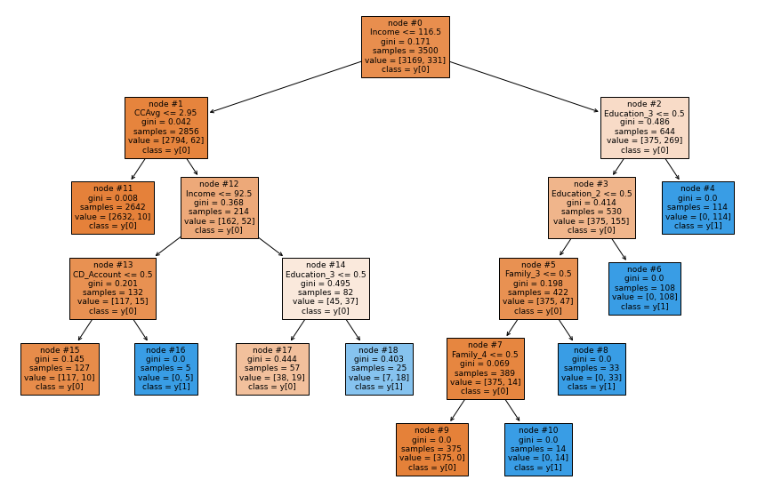

```python
plt.figure(figsize=(15,10))

tree.plot_tree(estimator,feature_names=feature_names,filled=True,fontsize=9,node_ids=True,class_names=True)
plt.show()
```

```python
# Text report showing the rules of a decision tree -
print(tree.export_text(estimator,feature_names=feature_names,show_weights=True))
```

```
|--- Income <= 116.50
|   |--- CCAvg <= 2.95
|   |   |--- weights: [2632.00, 10.00] class: 0
|   |--- CCAvg >  2.95
|   |   |--- Income <= 92.50
|   |   |   |--- CD_Account <= 0.50
|   |   |   |   |--- weights: [117.00, 10.00] class: 0
|   |   |   |--- CD_Account >  0.50
|   |   |   |   |--- weights: [0.00, 5.00] class: 1
|   |   |--- Income >  92.50
|   |   |   |--- Education_3 <= 0.50
|   |   |   |   |--- weights: [38.00, 19.00] class: 0
|   |   |   |--- Education_3 >  0.50
|   |   |   |   |--- weights: [7.00, 18.00] class: 1
|--- Income >  116.50
|   |--- Education_3 <= 0.50
|   |   |--- Education_2 <= 0.50
|   |   |   |--- Family_3 <= 0.50
|   |   |   |   |--- Family_4 <= 0.50
|   |   |   |   |   |--- weights: [375.00, 0.00] class: 0
|   |   |   |   |--- Family_4 >  0.50
|   |   |   |   |   |--- weights: [0.00, 14.00] class: 1
|   |   |   |--- Family_3 >  0.50
|   |   |   |   |--- weights: [0.00, 33.00] class: 1
|   |   |--- Education_2 >  0.50
|   |   |   |--- weights: [0.00, 108.00] class: 1
|   |--- Education_3 >  0.50
|   |   |--- weights: [0.00, 114.00] class: 1
```

```python
# importance of features in the tree building ( The importance of a feature is computed as the
#(normalized) total reduction of the 'criterion' brought by that feature. It is also known as the Gini importance )

print (pd.DataFrame(estimator.feature_importances_, columns = ["Imp"], index = X_train.columns).sort_values(by = 'Imp', ascending = False))

#Here we will see that importance of features has increased
```

```
                         Imp
Income              0.335478
Education_2         0.258373
Education_3         0.188599
Family_3            0.107563
Family_4            0.051352
CCAvg               0.043100
CD_Account          0.015535
Age                 0.000000
Experience          0.000000
Mortgage            0.000000
Securities_Account  0.000000
Online              0.000000
CreditCard          0.000000
Family_2            0.000000
```

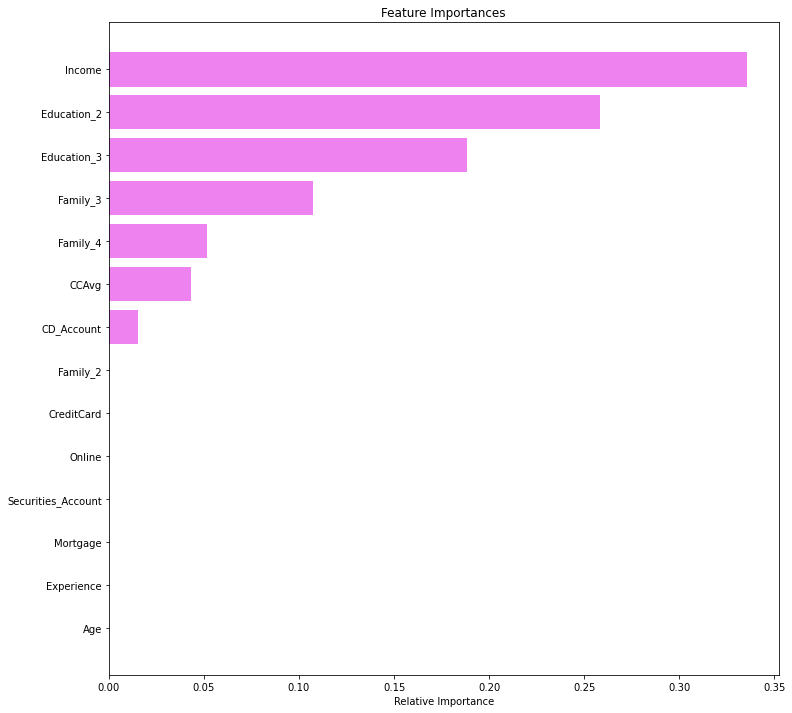

```python
importances = estimator.feature_importances_
indices = np.argsort(importances)

plt.figure(figsize=(12,12))
plt.title('Feature Importances')
plt.barh(range(len(indices)), importances[indices], color='violet', align='center')
plt.yticks(range(len(indices)), [feature_names[i] for i in indices])
plt.xlabel('Relative Importance')
plt.show()
```

## Post-Pruning

- Post pruning might give even better results, since there is quite a good possibility that we might neglect some hyperparameters, post pruning will take care of all that.

```python
clf = DecisionTreeClassifier(random_state=1)
path = clf.cost_complexity_pruning_path(X_train, y_train)
ccp_alphas, impurities = path.ccp_alphas, path.impurities
```

```python
pd.DataFrame(path)
```

|  | ccp_alphas | impurities |
| --- | --- | --- |
| 0 | 0.000000 | 0.000000 |
| 1 | 0.000268 | 0.000536 |
| 2 | 0.000268 | 0.001609 |
| 3 | 0.000275 | 0.002710 |
| 4 | 0.000278 | 0.003824 |
| ... | ... | ... |
| 22 | 0.006473 | 0.034659 |
| 23 | 0.007712 | 0.042372 |
| 24 | 0.016154 | 0.058525 |
| 25 | 0.032821 | 0.124167 |
| 26 | 0.047088 | 0.171255 |

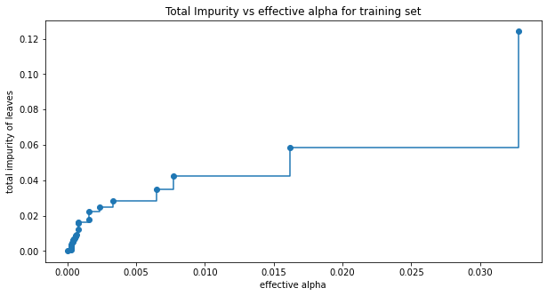

```python
fig, ax = plt.subplots(figsize=(10,5))
ax.plot(ccp_alphas[:-1], impurities[:-1], marker='o', drawstyle="steps-post")
ax.set_xlabel("effective alpha")
ax.set_ylabel("total impurity of leaves")
ax.set_title("Total Impurity vs effective alpha for training set")
plt.show()
```

Next, we train a decision tree using the effective alphas. The last value in `ccp_alphas` is the alpha value that prunes the whole tree, leaving the tree, `clfs[-1]`, with one node.

```python
clfs = []
for ccp_alpha in ccp_alphas:
    clf = DecisionTreeClassifier(random_state=1, ccp_alpha=ccp_alpha)
    clf.fit(X_train, y_train)
    clfs.append(clf)
print("Number of nodes in the last tree is: {} with ccp_alpha: {}".format(
      clfs[-1].tree_.node_count, ccp_alphas[-1]))
```

```
Number of nodes in the last tree is: 1 with ccp_alpha: 0.04708834100596768
```

For the remainder, we remove the last element in `clfs` and `ccp_alphas`, because it is the trivial tree with only one node. Here we show that the number of nodes and tree depth decreases as alpha increases.

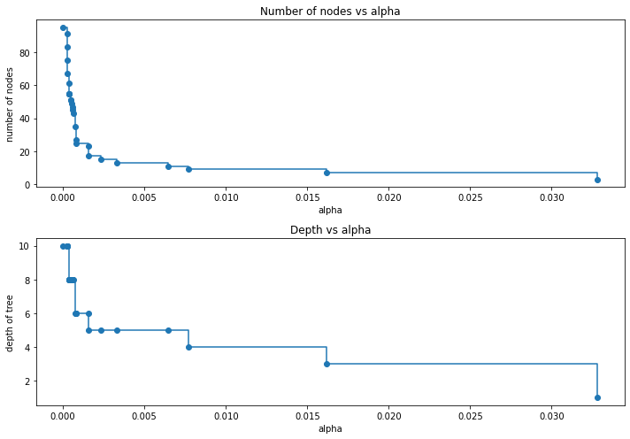

```python
clfs = clfs[:-1]
ccp_alphas = ccp_alphas[:-1]

node_counts = [clf.tree_.node_count for clf in clfs]
depth = [clf.tree_.max_depth for clf in clfs]
fig, ax = plt.subplots(2, 1,figsize=(10,7))
ax[0].plot(ccp_alphas, node_counts, marker='o', drawstyle="steps-post")
ax[0].set_xlabel("alpha")
ax[0].set_ylabel("number of nodes")
ax[0].set_title("Number of nodes vs alpha")
ax[1].plot(ccp_alphas, depth, marker='o', drawstyle="steps-post")
ax[1].set_xlabel("alpha")
ax[1].set_ylabel("depth of tree")
ax[1].set_title("Depth vs alpha")
fig.tight_layout()
```